# Plotting Likelihood function

Chetana Jamadar

2023-01-03

1. Generate a random sample of size n=50 from Poisson(λ = 5)distribution. Plot a likelihood function against the different values of λ and check whether likelihood function attains maxima at i)λ = X(sample mean) ii) λ = 5

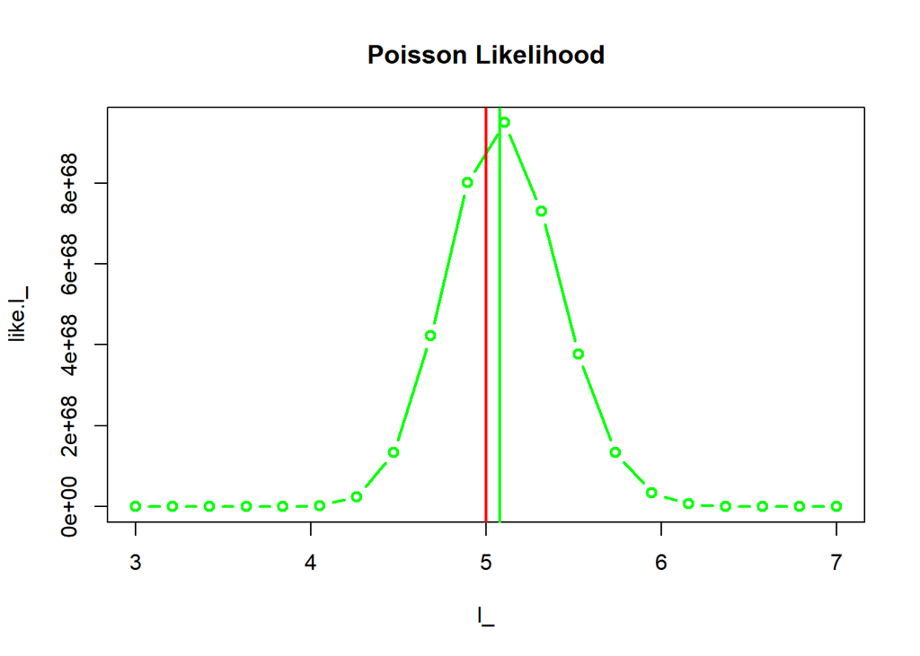

```r
n=50
lambda=5
x=rpois(n,lambda)
m=mean(x)
l_=seq(3,7,length.out =20)
like.l_=exp(-n*l_)*(l_)^(sum(x))
plot(l_,like.l_,type="b",col="green",lwd=2,main="Poisson Likelihood")
abline(v=m,col="green",lwd=2)
abline(v=lambda,col="red",lwd=2)
```

2. Generate a random sample of size n=50 from Bernoulli(P = 0.8) distribution. Plot a likelihood function against the different values of P and check whether likelihood function attains maxima at i)P = X(sample mean) ii) P = 0.8

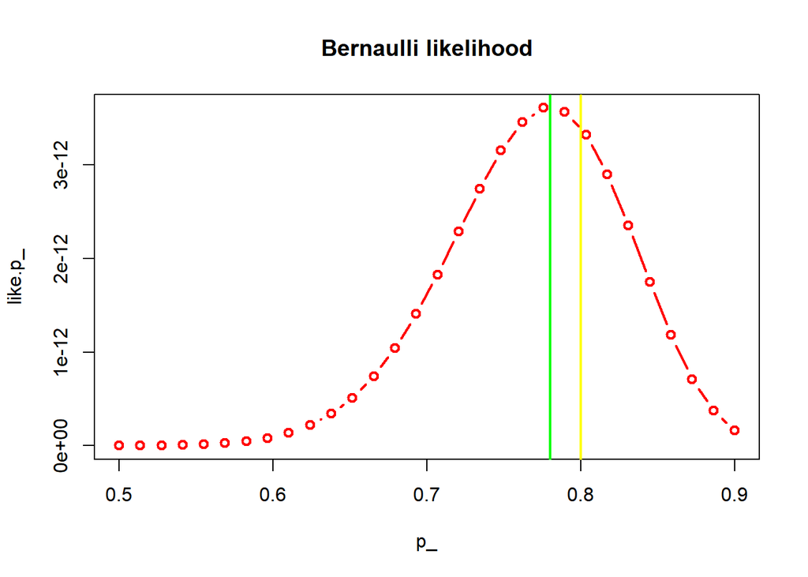

```r
P=0.8; n=50;
x=rbinom(50,1,0.8)
m=mean(x)
p_=seq(0.5,0.9,length.out = 30)
like.p_=(p_)^(sum(x))*(1-p_)^(n-sum(x))
plot(p_,like.p_,type="b",col="red",lwd=2,main="Bernaulli likelihood")
abline(v=m,col="green",lwd=2)
abline(v=P,col="yellow",lwd=2)
```

3. Generate a random sample of size n=20 from Normal(µ = 10,σ2 = 1) distribution. Plot a likelihood function for different values of µ when σ = 1 is known and check whether likelihood function attains maxima at i)µ = X(sample mean) ii) µ = 10

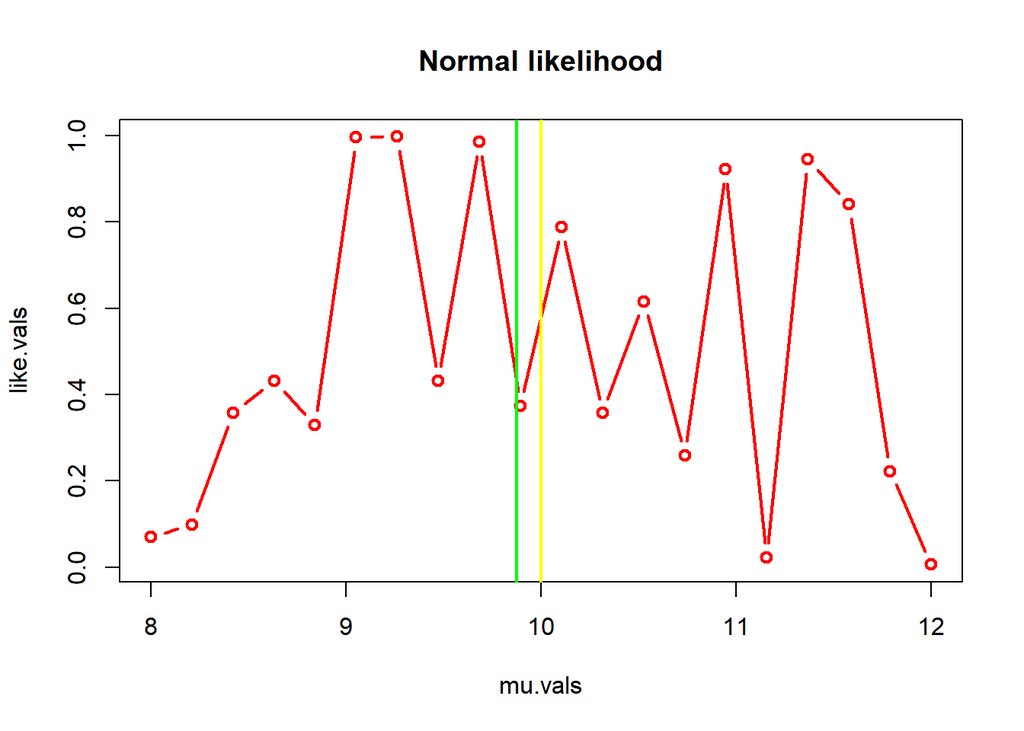

```r
mu=10; s=1; n=20
x=rnorm(20,10,1)
m=mean(x)
mu.vals=seq(8,12,length.out=20)
like.vals=exp((sum(-1/2)*(x-mu.vals)^2))
plot(mu.vals,like.vals,type="b",col="red",lwd=2,main="Normal likelihood")
abline(v=m,col="green",lwd=2)
abline(v=mu,col="yellow",lwd=2)
```

4. Draw a random of size n=10 from Exponential distribution with mean θ.Plot a likelihood function and check whether likelihood function attains maxima at i)θ = X ii) θ = X −0.5

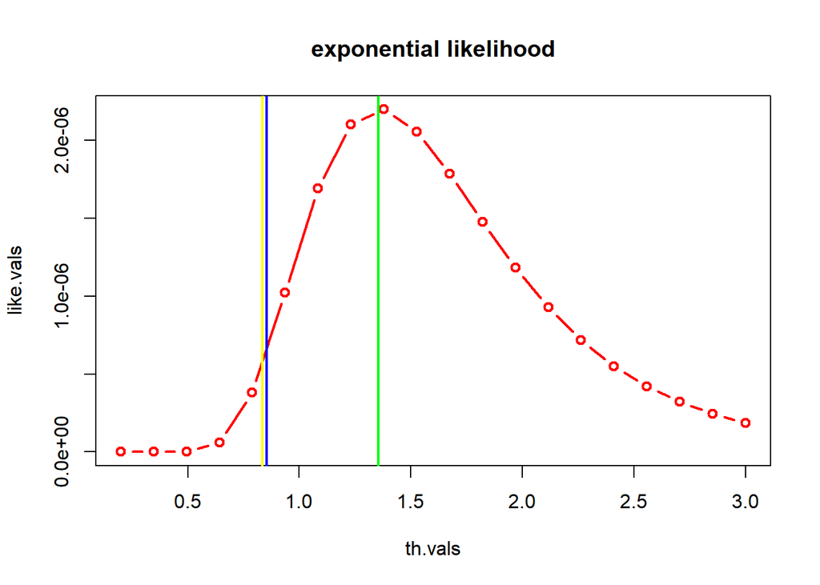

```r
th=1/1.2;n=10
x=rexp(10,th)
m1=mean(x)
m2=mean(x)-0.5
th.vals=seq(0.2,3,length.out=20)
like.vals=(1/th.vals)^n*exp(-sum(x)/th.vals)
plot(th.vals,like.vals,type="b",col="red",lwd=2,
main="exponential likelihood")
abline(v=m1,col="green",lwd=2)
abline(v=m2,col="blue",lwd=2)
abline(v=th,col="yellow",lwd=2)
```

5. Consider a random sample of size n=10 fromU (0,θ) distribution. 2.06874 5.82498 2.65698 3.58650 2.78196 1.36005 4.49083 5.74037 3.41361 1.36519 Plot a likelihood function and check whether likelihood function attains maxima at i)θ = 2X ii) θ = X(n)

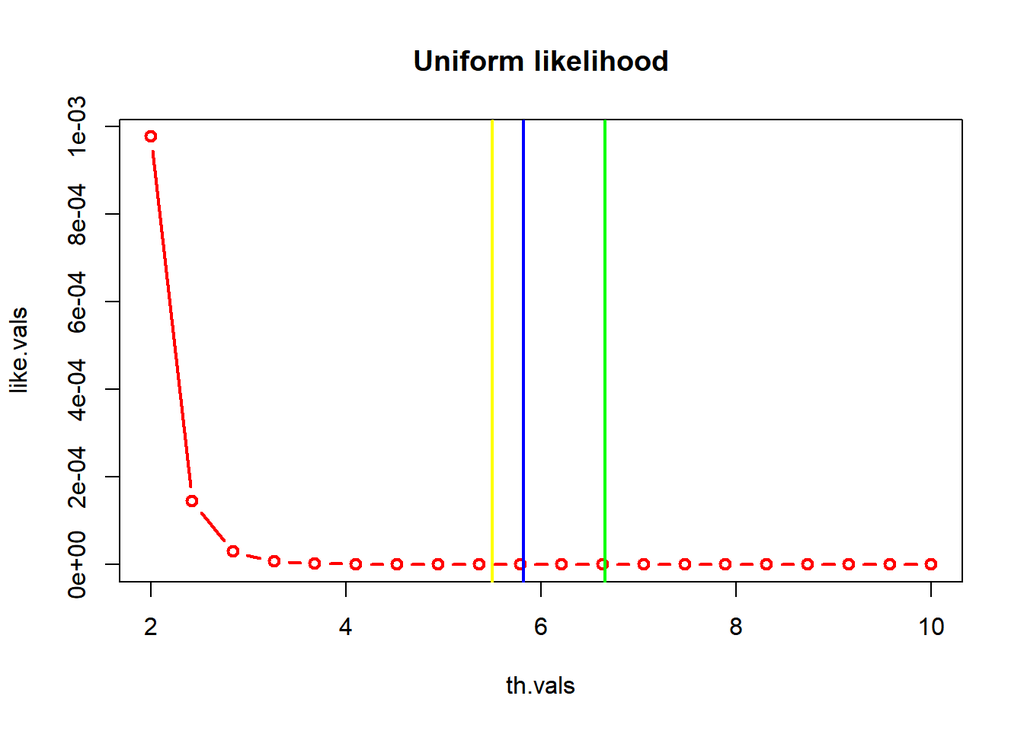

```r
th=5.5
n=10
x=c(2.06874,5.82498,2.65698,3.58650,2.78196,1.36005,4.49083,5.74037,
3.41361,1.36519)
m1=2*mean(x)
m2=max(x)
th.vals=seq(2,10,length.out=20)
like.vals=(1/th.vals)^n
plot(th.vals,like.vals,type="b",col="red",lwd=2,main="Uniform likelihood")
abline(v=m1,col="green",lwd=2)
abline(v=th,col="yellow",lwd=2)
abline(v=m2,col="blue",lwd=2)
```